# Predictive Model for Stock Movement - Case Study

##### Created on 2022-08-30

### Background: Machine Learning Algorithms are very useful to predict movement of stock-either to predict price or direction. In Spite of a lot of uncertainty, the well trained models can help to develop successful trading strategies. In this case study, we consider one of the leading global IT companies-Infosys and predict its next day movement using various ML algorithms.

### Objective: To predict closing price direction of Infosys stock on day t+1 relative to day t .

### Libraries used:

| Library | Application |
| --- | --- |
| pandas | To handle data frames in python |
| yfinance | To download stock data |
| matplotlib/seaborn | Plotting graphs |
| statsmodels | To implement Ordinary Least Squares(OLS) method of linear regression |
| sklearn | To implement ML algorithms |
| warnings | To disable warnings |

```python
#Upgrade Pandas library to version >1.2.0 if pd.plot() doesn't work
# To know the version of your package print(packagename.__version__)
#To install the package of a specific version >> pip install 'PackageName==1.2.0'
import pandas as pd
import numpy as np
#pip install yfinance before importing
import yfinance as yf

import matplotlib.pyplot as plt
import seaborn as sns

from statsmodels.formula.api import ols

import matplotlib.pyplot as plt
from sklearn.metrics import classification_report

#BLR
from sklearn.model_selection import train_test_split
import statsmodels.formula.api as smf

#NB
from sklearn.naive_bayes import GaussianNB, MultinomialNB

from sklearn.metrics import confusion_matrix, f1_score, precision_score, recall_score, accuracy_score,roc_curve, roc_auc_score

#KNN
from sklearn.preprocessing import StandardScaler
from sklearn.neighbors import KNeighborsClassifier
import warnings
warnings.filterwarnings("ignore", category=FutureWarning)
```

### Yahoo Finance Tickers Used

| Ticker Name | Description |
| --- | --- |
| INFY | Infosys Limited is an Indian multinational information technology company that provides business consulting, information technology and outsourcing services. |
| NASDAQ | The Nasdaq Stock Market is an American stock exchange based in New York City |

```python
ticker = 'INFY'
infy = yf.download(ticker+'.NS','2020-12-01','2022-06-30' ).round(2).reset_index()[['Date','Open','High','Low','Close']]
infy
```

```
[*********************100%***********************]  1 of 1 completed
```

|  | Date | Open | High | Low | Close |
| --- | --- | --- | --- | --- | --- |
| 0 | 2020-12-01 | 1105.05 | 1140.25 | 1105.05 | 1137.85 |
| 1 | 2020-12-02 | 1134.00 | 1147.45 | 1121.00 | 1140.90 |
| 2 | 2020-12-03 | 1147.00 | 1147.00 | 1122.70 | 1126.45 |
| 3 | 2020-12-04 | 1125.00 | 1137.00 | 1115.00 | 1134.65 |
| 4 | 2020-12-07 | 1147.30 | 1153.00 | 1136.00 | 1143.50 |
| ... | ... | ... | ... | ... | ... |
| 387 | 2022-06-23 | 1439.80 | 1458.00 | 1433.00 | 1452.45 |
| 388 | 2022-06-24 | 1458.00 | 1467.50 | 1428.90 | 1441.10 |
| 389 | 2022-06-27 | 1468.05 | 1484.00 | 1465.15 | 1474.60 |
| 390 | 2022-06-28 | 1469.00 | 1488.25 | 1453.00 | 1480.15 |
| 391 | 2022-06-29 | 1464.70 | 1477.00 | 1457.00 | 1463.25 |

392 rows × 5 columns

### Table of derived variables:

| Column Name | Description |
| --- | --- |
| Returns | percent change |
| Direction | Returns>0, Direction=1 & Returns<0, Direction =0 |
| CloseToOpen | Ratio of close/open |
| HighToLow | Ratio of high/low |
| Std_deviation | Rolling standard deviation(infy returns) for past one month |
| Direction_next | Shifting direction column |

### Deriving Variables

```python
infy['Returns'] = infy['Close'].pct_change()*100
infy['Direction'] = np.where(infy['Returns']>0,1,0)
infy['CloseToOpen'] = infy['Close']/infy['Open']
infy['HighToLow'] = infy['High']/infy['Low']
infy['Std_deviation'] = infy.Returns.rolling(21).std()
infy['Direction_next'] = infy['Direction'].shift(-1)
```

```python
infy
```

|  | Date | Open | High | Low | Close | Returns | Direction | CloseToOpen | HighToLow | Std_deviation | Direction_next |
| --- | --- | --- | --- | --- | --- | --- | --- | --- | --- | --- | --- |
| 0 | 2020-12-01 | 1105.05 | 1140.25 | 1105.05 | 1137.85 | NaN | 0 | 1.029682 | 1.031854 | NaN | 1.0 |
| 1 | 2020-12-02 | 1134.00 | 1147.45 | 1121.00 | 1140.90 | 0.268049 | 1 | 1.006085 | 1.023595 | NaN | 0.0 |
| 2 | 2020-12-03 | 1147.00 | 1147.00 | 1122.70 | 1126.45 | -1.266544 | 0 | 0.982084 | 1.021644 | NaN | 1.0 |
| 3 | 2020-12-04 | 1125.00 | 1137.00 | 1115.00 | 1134.65 | 0.727951 | 1 | 1.008578 | 1.019731 | NaN | 1.0 |
| 4 | 2020-12-07 | 1147.30 | 1153.00 | 1136.00 | 1143.50 | 0.779976 | 1 | 0.996688 | 1.014965 | NaN | 1.0 |
| ... | ... | ... | ... | ... | ... | ... | ... | ... | ... | ... | ... |
| 387 | 2022-06-23 | 1439.80 | 1458.00 | 1433.00 | 1452.45 | 1.057575 | 1 | 1.008786 | 1.017446 | 1.980550 | 0.0 |
| 388 | 2022-06-24 | 1458.00 | 1467.50 | 1428.90 | 1441.10 | -0.781438 | 0 | 0.988409 | 1.027014 | 1.981831 | 1.0 |
| 389 | 2022-06-27 | 1468.05 | 1484.00 | 1465.15 | 1474.60 | 2.324613 | 1 | 1.004462 | 1.012866 | 1.963412 | 1.0 |
| 390 | 2022-06-28 | 1469.00 | 1488.25 | 1453.00 | 1480.15 | 0.376373 | 1 | 1.007590 | 1.024260 | 1.686471 | 0.0 |
| 391 | 2022-06-29 | 1464.70 | 1477.00 | 1457.00 | 1463.25 | -1.141776 | 0 | 0.999010 | 1.013727 | 1.672915 | NaN |

392 rows × 11 columns

### Visualizing Direction

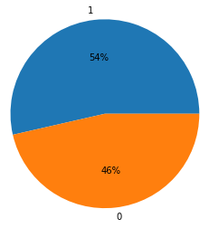

```python
dir_df = infy['Direction'].value_counts().reset_index()
plt.pie(dir_df['Direction'],labels = dir_df['index'],autopct="%0.0f%%",radius = 1.2) #Hide text
plt.show()
```

### Boxplot for derived variables grouped by Direction_next

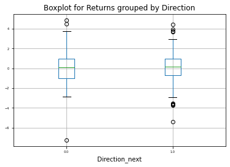

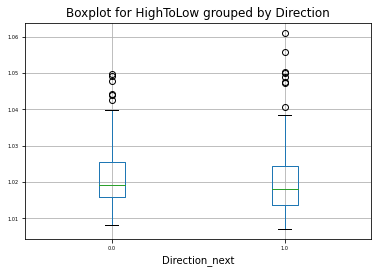

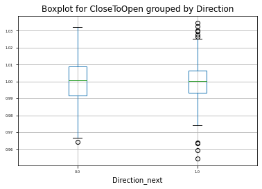

```python
#sns.boxplot('HighToLow',hue = 'Direction',data = infy)
cols = ['Returns','HighToLow','CloseToOpen']
for i in cols:
    infy.boxplot(column = [i],by = 'Direction_next',fontsize = 5)
    plt.title( 'Boxplot for '+ i +' grouped by Direction')
    plt.suptitle('') # that's what you're after
    plt.show()
```

### Downloading NASDAQ data and calculating returns

```python
nasdaq = yf.download('^IXIC','2020-12-01','2022-06-30' ).round(2).reset_index()[['Date','Open','High','Low','Close']]
nasdaq['Returns_ndq'] = nasdaq['Close'].pct_change()*100
nasdaq
```

```
[*********************100%***********************]  1 of 1 completed
```

|  | Date | Open | High | Low | Close | Returns_ndq |
| --- | --- | --- | --- | --- | --- | --- |
| 0 | 2020-11-30 | 12224.25 | 12244.65 | 12027.16 | 12198.74 | NaN |
| 1 | 2020-12-01 | 12313.36 | 12405.79 | 12263.93 | 12355.11 | 1.281854 |
| 2 | 2020-12-02 | 12285.75 | 12360.06 | 12217.35 | 12349.37 | -0.046459 |
| 3 | 2020-12-03 | 12369.26 | 12439.02 | 12356.99 | 12377.18 | 0.225194 |
| 4 | 2020-12-04 | 12399.32 | 12464.23 | 12376.44 | 12464.23 | 0.703310 |
| ... | ... | ... | ... | ... | ... | ... |
| 393 | 2022-06-23 | 11137.68 | 11260.27 | 11046.28 | 11232.19 | 1.620453 |
| 394 | 2022-06-24 | 11351.31 | 11613.23 | 11337.78 | 11607.62 | 3.342447 |
| 395 | 2022-06-27 | 11661.02 | 11677.49 | 11487.07 | 11524.55 | -0.715651 |
| 396 | 2022-06-28 | 11542.24 | 11635.85 | 11177.68 | 11181.54 | -2.976342 |
| 397 | 2022-06-29 | 11160.22 | 11226.33 | 11072.19 | 11177.89 | -0.032643 |

398 rows × 6 columns

### Merging Infy and Nasdaq data

```python
finaldata = pd.merge(infy,nasdaq[['Date','Returns_ndq']],on ='Date',how = 'outer')
finaldata = finaldata.sort_values(by = 'Date')
finaldata
```

|  | Date | Open | High | Low | Close | Returns | Direction | CloseToOpen | HighToLow | Std_deviation | Direction_next | Returns_ndq |
| --- | --- | --- | --- | --- | --- | --- | --- | --- | --- | --- | --- | --- |
| 392 | 2020-11-30 | NaN | NaN | NaN | NaN | NaN | NaN | NaN | NaN | NaN | NaN | NaN |
| 0 | 2020-12-01 | 1105.05 | 1140.25 | 1105.05 | 1137.85 | NaN | 0.0 | 1.029682 | 1.031854 | NaN | 1.0 | 1.281854 |
| 1 | 2020-12-02 | 1134.00 | 1147.45 | 1121.00 | 1140.90 | 0.268049 | 1.0 | 1.006085 | 1.023595 | NaN | 0.0 | -0.046459 |
| 2 | 2020-12-03 | 1147.00 | 1147.00 | 1122.70 | 1126.45 | -1.266544 | 0.0 | 0.982084 | 1.021644 | NaN | 1.0 | 0.225194 |
| 3 | 2020-12-04 | 1125.00 | 1137.00 | 1115.00 | 1134.65 | 0.727951 | 1.0 | 1.008578 | 1.019731 | NaN | 1.0 | 0.703310 |
| ... | ... | ... | ... | ... | ... | ... | ... | ... | ... | ... | ... | ... |
| 387 | 2022-06-23 | 1439.80 | 1458.00 | 1433.00 | 1452.45 | 1.057575 | 1.0 | 1.008786 | 1.017446 | 1.980550 | 0.0 | 1.620453 |
| 388 | 2022-06-24 | 1458.00 | 1467.50 | 1428.90 | 1441.10 | -0.781438 | 0.0 | 0.988409 | 1.027014 | 1.981831 | 1.0 | 3.342447 |
| 389 | 2022-06-27 | 1468.05 | 1484.00 | 1465.15 | 1474.60 | 2.324613 | 1.0 | 1.004462 | 1.012866 | 1.963412 | 1.0 | -0.715651 |
| 390 | 2022-06-28 | 1469.00 | 1488.25 | 1453.00 | 1480.15 | 0.376373 | 1.0 | 1.007590 | 1.024260 | 1.686471 | 0.0 | -2.976342 |
| 391 | 2022-06-29 | 1464.70 | 1477.00 | 1457.00 | 1463.25 | -1.141776 | 0.0 | 0.999010 | 1.013727 | 1.672915 | NaN | -0.032643 |

410 rows × 12 columns

### Dropping nulls

```python
finaldata_rm = finaldata.dropna()
len(finaldata_rm)
```

```
358
```

## Modelling

Steps Required:

1. Splitting Data into Train and Test data sets
2. Building Model
3. Predicting probabilities
4. Generating Classification Report
5. Computing AUC value for ROC curve

### Model 1. Binary Logistic Regression

Splitting Data into Train and Test data sets

```python
X_train, X_test = train_test_split(finaldata_rm, test_size=0.3,random_state = 0)
```

```python
X_train.shape
```

```
(250, 12)
```

```python
X_test.shape
```

```
(108, 12)
```

```python
threshold = 0.54 #based on pie chart above
```

Building Model

```python
model=smf.logit(formula = 'Direction_next ~  Returns + CloseToOpen + HighToLow + Std_deviation + Returns_ndq ', data = X_train).fit()
model.summary()
```

```
Optimization terminated successfully.
         Current function value: 0.654760
         Iterations 5
```

Logit Regression Results

| Dep. Variable: | Direction_next | No. Observations: | 250 |
| --- | --- | --- | --- |
| Model: | Logit | Df Residuals: | 244 |
| Method: | MLE | Df Model: | 5 |
| Date: | Mon, 12 Sep 2022 | Pseudo R-squ.: | 0.05499 |
| Time: | 11:25:33 | Log-Likelihood: | -163.69 |
| converged: | True | LL-Null: | -173.21 |
| Covariance Type: | nonrobust | LLR p-value: | 0.001882 |

|  | coef | std err | z | P>\|z\| | [0.025 | 0.975] |
| --- | --- | --- | --- | --- | --- | --- |
| Intercept | 50.9151 | 24.271 | 2.098 | 0.036 | 3.344 | 98.486 |
| Returns | 0.1431 | 0.144 | 0.992 | 0.321 | -0.140 | 0.426 |
| CloseToOpen | -26.3845 | 17.509 | -1.507 | 0.132 | -60.703 | 7.933 |
| HighToLow | -23.8529 | 16.962 | -1.406 | 0.160 | -57.097 | 9.391 |
| Std_deviation | -0.0743 | 0.334 | -0.222 | 0.824 | -0.729 | 0.581 |
| Returns_ndq | 0.2997 | 0.088 | 3.409 | 0.001 | 0.127 | 0.472 |

Predicting probabilities

```python
predicted_values1=model.predict(X_test)
```

Generating Classification Report

```python
predicted_class1=np.zeros(predicted_values1.shape)
predicted_class1[predicted_values1>threshold]=1
from sklearn.metrics import classification_report
print(classification_report(X_test['Direction_next'],predicted_class1))
```

```
              precision    recall  f1-score   support

         0.0       0.52      0.52      0.52        44
         1.0       0.67      0.67      0.67        64

    accuracy                           0.61       108
   macro avg       0.60      0.60      0.60       108
weighted avg       0.61      0.61      0.61       108
```

Computing AUC value for ROC curve

```python
auc = roc_auc_score(X_test['Direction_next'],predicted_values1)
print('AUC: %.3f' % auc)
```

```
AUC: 0.596
```

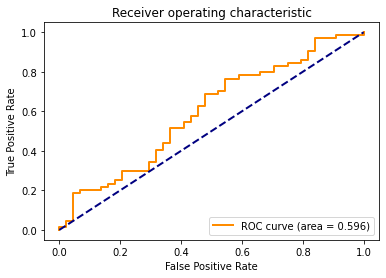

```python
BLRfpr, BLRtpr, thresholds = roc_curve(X_test['Direction_next'],predicted_values1)

# plot the roc curve for the model
plt.figure()
lw = 2
plt.plot(BLRfpr, BLRtpr, color='darkorange',lw=lw, label='ROC curve (area = %0.3f)' % auc)
plt.plot([0, 1], [0, 1], color='navy', lw=lw, linestyle='--')
plt.axis('tight')
plt.xlabel('False Positive Rate');plt.ylabel('True Positive Rate')
plt.title('Receiver operating characteristic')
plt.legend(loc="lower right")
plt.show()
```

### Comment: The overall model accuracy is 61% and sensitivity is 67%

### Model 2. Naive Bayes

Splitting Data into Train and Test data sets

```python
train_cols =['Returns','CloseToOpen','HighToLow','Std_deviation','Returns_ndq']
```

```python
X = finaldata_rm.loc[:,train_cols]
y = finaldata_rm.loc[:, 'Direction_next']

X_train, X_test, y_train, y_test = train_test_split(X, y,
                                                   test_size=0.30,
                                                   random_state = 0)
```

Building Model

```python
NBmodel = GaussianNB()

NBmodel.fit(X_train, y_train)
```

```
GaussianNB()
```

Predicting probabilities

```python
predprob_test = NBmodel.predict_proba(X_test)
```

```python
pred_test = np.where(predprob_test[:,1] > threshold, 1, 0)
```

Generating Classification Report

```python
print(classification_report(y_test,pred_test))
```

```
              precision    recall  f1-score   support

         0.0       0.53      0.52      0.53        44
         1.0       0.68      0.69      0.68        64

    accuracy                           0.62       108
   macro avg       0.61      0.61      0.61       108
weighted avg       0.62      0.62      0.62       108
```

Computing AUC value for ROC curve

```python
auc = roc_auc_score(y_test,predprob_test[:,1])
print('AUC: %.3f' % auc)
```

```
AUC: 0.615
```

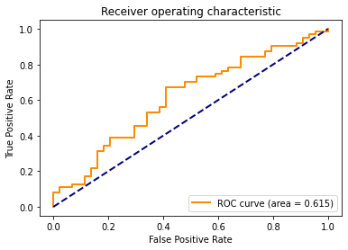

```python
NBfpr, NBtpr, thresholds = roc_curve(y_test, predprob_test[:,1])

# plot the roc curve for the model
plt.figure()
lw = 2
plt.plot(NBfpr, NBtpr, color='darkorange',lw=lw, label='ROC curve (area = %0.3f)' % auc)
plt.plot([0, 1], [0, 1], color='navy', lw=lw, linestyle='--')
plt.axis('tight')
plt.xlabel('False Positive Rate');plt.ylabel('True Positive Rate')
plt.title('Receiver operating characteristic')
plt.legend(loc="lower right")
plt.show()
```

### Comment : The model accuracy is 62% and sensitivity is 69%

### Model 3. K Nearest Neighbours (KNN)

Scaling train data parameters (Note: This is an additional step in KNN)

```python
scaler = StandardScaler()
scaler.fit(X_train)

X_train = scaler.transform(X_train)
X_test = scaler.transform(X_test)
X_train
```

```
array([[ 0.83128307,  1.6494645 ,  1.99895092,  0.95139109,  0.34349157],
       [-0.13004668, -0.26648625, -0.27665857,  0.56339558,  0.1274948 ],
       [ 0.8202016 ,  0.30590071, -0.02528109, -1.05589022,  0.07325798],
       ...,
       [-0.34743534,  0.14214421, -1.29383092, -1.12717099,  0.20814903],
       [-0.04173702,  0.2490027 , -0.54719512, -0.28339087,  0.7294939 ],
       [ 1.20783851,  0.91765891,  0.5163493 , -1.15496204,  0.22578332]])
```

Building Model

```python
KNNclassifier = KNeighborsClassifier(n_neighbors =
                                     int(np.sqrt(len(X)).round()))
# using thumb rule k ~= sqrt(n)
KNNclassifier.fit(X_train, y_train)
```

```
KNeighborsClassifier(n_neighbors=19)
```

Predicting labels

```python
y_pred = KNNclassifier.predict(X_test)
```

```python
y_pred
```

```
array([1., 1., 0., 0., 1., 1., 1., 0., 0., 1., 1., 1., 0., 1., 1., 1., 1.,
       0., 0., 1., 1., 0., 0., 1., 0., 0., 1., 1., 1., 1., 0., 1., 0., 1.,
       0., 1., 1., 1., 0., 0., 1., 0., 1., 1., 0., 1., 0., 1., 1., 1., 1.,
       1., 1., 1., 1., 1., 0., 1., 1., 0., 1., 0., 1., 1., 0., 0., 1., 1.,
       1., 1., 1., 1., 0., 0., 0., 1., 1., 1., 1., 1., 1., 1., 1., 0., 0.,
       0., 1., 1., 0., 0., 1., 0., 0., 1., 1., 0., 0., 0., 0., 1., 0., 1.,
       0., 1., 0., 1., 1., 1.])
```

Generating Classification Report

```python
print(classification_report(y_test,y_pred))
```

```
              precision    recall  f1-score   support

         0.0       0.39      0.36      0.38        44
         1.0       0.58      0.61      0.60        64

    accuracy                           0.51       108
   macro avg       0.49      0.49      0.49       108
weighted avg       0.50      0.51      0.51       108
```

### Comment : The model accuracy is 51% and sensitivity is 61%

## Conclusion:

The Naive Baye's has performed little better than binary logistic regression and K nearest neighbours methods. However, the model performance can be improved by adding more predictors used in technical analysis such as Relative Strength Index (RSI), ADX etc